# A tutorial on variant filtering on FFPE samples using Ideafix

#### Using alternative classification thresholds (recommended)

The following lines show one possible alternative to select a custom threshold. First of all, we will observe the distribution of the scores:

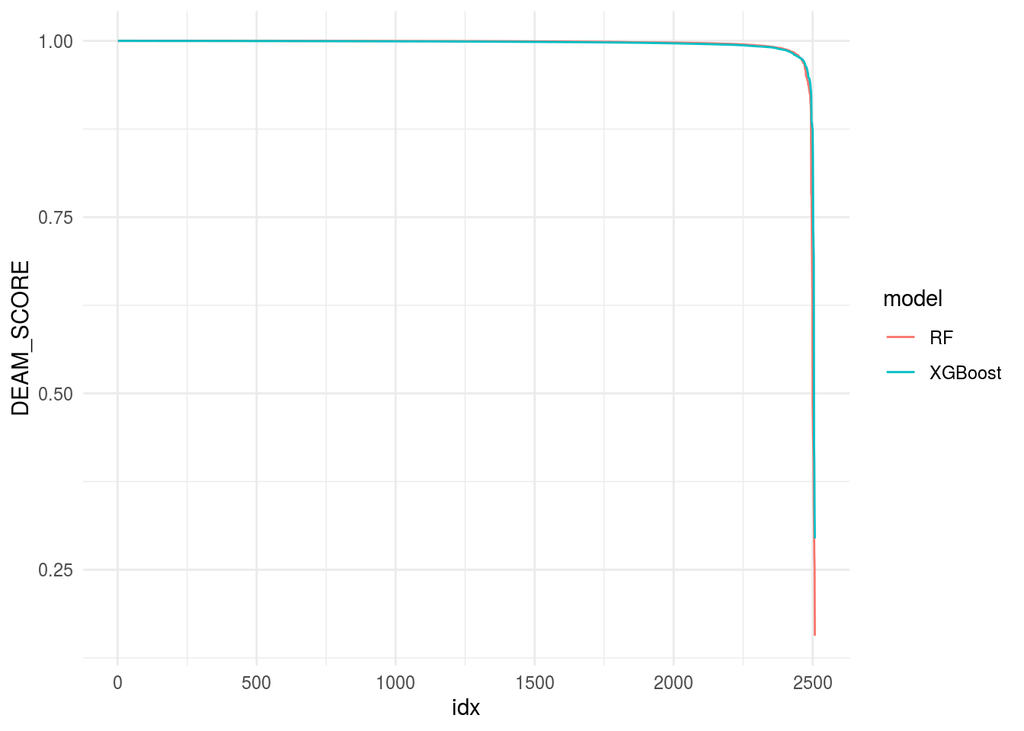

```r
library(ggplot2)
library(dplyr)
all_predictions <- bind_rows(list(RF = predictions_RF, XGBoost = predictions_XGBoost), .id = 'model')
all_predictions %>%
  group_by(model) %>%
  arrange(desc(DEAM_SCORE)) %>%
  mutate(idx = row_number()) %>%
  ungroup() %>%
  ggplot(aes(x = idx, y = DEAM_SCORE, colour = model)) +
  geom_line() +
  theme_minimal()
```

As DEAM_SCORE is proportional to the degree of certainty on a variant being a deamination, this plot shows us that there is a large number of variants that are highly likely deaminations and that the two models make very similar predictions. An interesting alternative threshold would be that at which the score starts to drop rapidly, but the final election should be influenced by the steps to be taken with the variants hereafter. For instance, if the idea is to continue with a biological enrichment analysis, we can be quite permissive with the threshold as the analysis will filter additional variants. In such case, taking a close look at the curves, the threshold could be around 0.97.

```r
thr_str <- 0.97
predictions_XGBoost_str <- predictions_XGBoost %>%
  mutate(DEAMINATION = ifelse(DEAM_SCORE >= thr_str, "deamination", "non-deamination"))
predictions_RF_str <- predictions_RF %>%
  mutate(DEAMINATION = ifelse(DEAM_SCORE >= thr_str, "deamination", "non-deamination"))

table(factor(predictions_RF_str$DEAMINATION, levels = c("deamination", "non-deamination")),
      factor(predictions_XGBoost_str$DEAMINATION, levels = c("deamination", "non-deamination")))
```

```
#>
#>                   deamination non-deamination
#>   deamination            2448              17
#>   non-deamination          22              21
```

If, instead, there are no additional filtering steps, it is a good idea to opt for a more conservative threshold, such as 0.75.

```r
thr_sft <- 0.75
predictions_XGBoost_sft <- predictions_XGBoost %>%
  mutate(DEAMINATION = ifelse(DEAM_SCORE >= thr_sft, "deamination", "non-deamination"))
predictions_RF_sft <- predictions_RF %>%
  mutate(DEAMINATION = ifelse(DEAM_SCORE >= thr_sft, "deamination", "non-deamination"))

table(factor(predictions_RF_sft$DEAMINATION, levels = c("deamination", "non-deamination")),
      factor(predictions_XGBoost_sft$DEAMINATION, levels = c("deamination", "non-deamination")))
```

```
#>
#>                   deamination non-deamination
#>   deamination            2495               1
#>   non-deamination           6               6
```

We can compare the contingency tables between these labels and the ones originally provided (in which a thresholds between 0.95 and 0.96 were used):

```r
table(factor(predictions_RF$DEAMINATION, levels = c("deamination", "non-deamination")),
      factor(predictions_XGBoost$DEAMINATION, levels = c("deamination", "non-deamination")))
```

```
#>
#>                   deamination non-deamination
#>   deamination            2465               6
#>   non-deamination          24              13
```

As expected, as we raise the threshold, less deaminations are called in favour of non-deaminations.

### Step 4: Annotation of class label into original vcf file or to separate file (optional)

There are two options to output the class scores and labels. The most straightforward is to append them to the original vcf file. vcf format is the most common variant format and it is supported by almost all tools that work with this kind of data, so this is probably the easiest way of working with ideafix labels from here on. This can be done as follows:

```r
outname <- "mysample_classified"
outfolder <- "."
annotate_deaminations(classification = predictions_XGBoost, format = "vcf", vcf_filename = vcf_filename, outfolder = outfolder, outname = outname)
```

```
#> Writing vcf file to ./mysample_classified.vcf
```

The resulting file will have two new elements (related to the deamination score and deamination label) in the INFO field of each PASS-filtering C:G > T:A variant, as in the following example:

```r
cmd <- sprintf("grep PASS %s.vcf | grep DEAM | head -1", file.path(outfolder, outname))
cat(system(cmd, intern = TRUE))
```

[output not shown]

The two elements are described in the header of the resulting vcf file:

```r
cmd <- sprintf("bcftools view -h %s.vcf | grep DEAM", file.path(outfolder, outname))
system(cmd, intern = TRUE)
```

```
#> [1] "##INFO=<ID=DEAM_SCORE,Number=1,Type=Float,Description=\"Deamination score of the variant.\">"
#> [2] "##INFO=<ID=DEAMINATION,Number=1,Type=String,Description=\"Classification of the variant as deamination or non-deamination.\">"
#> [3] "##bcftools_annotateCommand=annotate -a /tmp/ideafix_preds.temp.gz -h /tmp/ideafix_preds.hdr -c CHROM,POS,REF,ALT,DEAM_SCORE,DEAMINATION -o ./mysample_classified.vcf /home/maitena/R/x86_64-pc-linux-gnu-library/3.4/ideafix/extdata/mysample_chr15.vcf; Date=Mon May 10 16:23:21 2021"
```

Instead, we can simply write the `predictions_XGBoost`(or the `predictions_RF`) object as it is to a different text file:

```r
annotate_deaminations(classification = predictions_XGBoost, format = "tsv", outname = "mysample_classified")
```

```
#> Writing tsv file to ./mysample_classified.txt
```

If we do not specify any file name in `outname`, the filename will default to ideafix_labels.txt

```r
annotate_deaminations(classification = predictions_XGBoost, format = "tsv")
```

```
#> Writing tsv file to ./ideafix_labels.txt
```